# welcome

## Self Insurance KPI APP

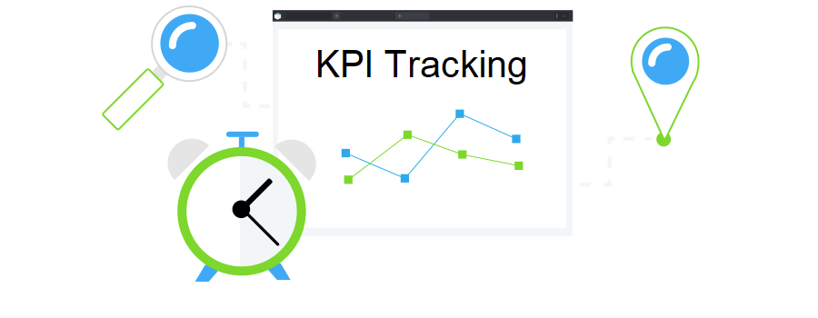

Welcome to the Self Insurance KPI Tracking R Shiny Web App!

Please review the below information before proceeding to the application.

Once you are done reviewing, click on the “Tour App” button to preview the application’s various features or “Dismiss” to begin using the application.

### Data

#### Data Overview

This application uses scrubbed, simulated claims and exposure data to represent the two core components of an actuarial data model:

- **Exposures** and
- **Claims** Data.

The data is further segmented into arbitrary segments using coverage specific fields.

**Exposure Data**

- For Worker’s Compensation the assumed exposure base is Payroll.
- For Auto Liability the assumed exposure base is miles driven.

*Note: to perform cross-coverage comparisons and aggregations the application includes a built in mechanism to convert to and from each exposure type.*

**Claims Data**

Claims data is simulated and aggregated into lossruns as of specific evaluation dates.

#### Considerations & Limitations

Please be aware of the following:

- Reported and Open Counts are grouped by occurrence and exclude incidents.
- Claim Details (i.e. everything except claim status and financials) are pulled from the loss run at the most recent evaluation date.
- The application currently only includes April, August, and December loss runs.
- Exposures are only able to be split by Year, Member, and Department. As a result, filtering down loss rate and frequency metrics using any other filters will produce differences between the numerator (filtered) and the denominator (unfiltered), thereby making the these metrics not-representative of true cost/counts relative to exposure.
- Payroll was not made available for all entities/member’s and as a result, when calculating Auto Liability frequency and loss rates using payroll as an exposure base, the application includes all members, but not an accompanying exposure base, skewing the metrics.
- All miles assumed to be part of Drivers Department.

### About

This purpose of this project is to provide a *Proof-of-Concept* web-application showcasing the ability to track various *Key Performance Indicators* related to Self-Insured or Captive Property-Casualty Insurance Entities using R Shiny.

Visit the following links for more details and to learn about the development of the application:

- [GitHub Repository](https://github.com/jimbrig/self-insurance-kpi-app)
- [File an Issue](https://github.com/jimbrig/self-insurance-kpi-app)

#### Performance Tracking of Key-Performance-Indicators (KPI)

Key performance indicators (KPI) are being used almost everywhere, either knowingly or not. These are specific measurable indicators, based on which a goal can be set and tracked.

Knowing what you want to achieve and by what measurable means (partial goals) you can get there, can be a half of success.

### Changelog

*All notable changes to this project will be documented in this file.*

- Live Version located on [GitHub Repository](https://github.com/jimbrig/self-insurance-kpi-app/blob/main/CHANGELOG.md)

#### Version 1.0.0 - 12-17-2021

##### Features

- Add serialized data files for data_prep
- Add data_preparation scripts, helpers functions, and workflows
- Add a Dockerfile
- Add derived data to shiny_app
- Add shiny app dependencies config file
- Add core shiny app R scripts
- Add coverage tab shiny module
- Add custom datatables and highcharts functions
- Add header buttons module
- Add custom shinytools.R functions
- Add currently DEPRECATED custom sign in / registration page
- Add more R helpers
- Add application static assets and markdown files

##### Testing

- Add unit tests to data_prep workflow

##### Config

- Initial repository scaffolding
- Add a cliff.toml config file for use with git-cliff to generate CHANGELOG.md
- Gitignore cached data_prep files
- Ignore various data folder contents

##### Deploy

- Add rsconnect configuration for deployment

*generated by git-cliff*

Jimmy Briggs | 2020